# Cheating on your math homework with SymPy

http://www.sympy.org

https://github.com/jocassid/Talks

What is (x+2)<sup>2</sup>?

```python
# The programmer's answer
def expr(x):
    return (x+2)**2

expr(5)
```

```
49
```

(x+2)(x+2)

x<sup>2</sup>+4x+4

Computer Algebra System (CAS)

A system which allows a computer to perform mathematical operations on symbols.

Other examples of CAS software include:

- Maple https://www.maplesoft.com
- Mathematica http://www.wolfram.com/mathematica

### What kinds of math can you do with SymPy?

- Algebra
- Geometry
- Linear Algebra (Matrices)
- Calculus
- Differential Equations (ODE & PDE modules)
- ... and many others

## Installation

`pip install sympy`

`conda install sympy`

```python
# Allows output to contain characters such as Greek letters, etc.  More on this later
from sympy import init_printing
init_printing()
```

```python
from sympy import symbols
x = symbols('x')
expr = (x+2)**2
expr
```

$$\left(x + 2\right)^{2}$$

```python
# Sympy doesn't automatically expand expressions (leaves it up to the user)
from sympy import expand
expanded = expand(expr)
expanded
```

$$x^{2} + 4 x + 4$$

```python
# To reverse the process use factor
from sympy import factor
factor(expanded)
```

$$\left(x + 2\right)^{2}$$

```python
# If I wanted to show my work while factoring the following
expr = x**2 -1*x - 6
expr
```

$$x^{2} - x - 6$$

```python
expr / (x-3)
```

$$\frac{x^{2} - x - 6}{x - 3}$$

```python
from sympy import simplify
simplify(expr / (x-3))
```

$$x + 2$$

```python
simplify(expr / (x-1))
```

$$\frac{x^{2} - x - 6}{x - 1}$$

```python
factor(expr)
```

$$\left(x - 3\right) \left(x + 2\right)$$

```python
from sympy import sympify
sympify('x**2 + sin(y)')
```

$$x^{2} + \sin{\left (y \right )}$$

## Basic Operations

```python
x, y = symbols('x y')
expr = x**2 + x
expr
```

$$x^{2} + x$$

```python
expr.subs(x, y+2)
```

$$y + \left(y + 2\right)^{2} + 2$$

```python
expr.subs(x, 1)
```

$$2$$

```python
from sympy import Eq
x, y = symbols('x y')
eqn = Eq(5, 2*x + 1)
```

```python
eqn
```

$$5 = 2 x + 1$$

```python
lhs = eqn.lhs
lhs
```

$$5$$

```python
rhs = eqn.rhs
rhs
```

$$2 x + 1$$

```python
try:
    eqn.lhs = eqn.lhs - 1
except AttributeError as ae:
    print(ae)
```

```
can't set attribute
```

```python
from sympy import solveset
solveset(eqn, x)
```

$$\left\{2\right\}$$

Solve the following equations for x and y: x + y = 6 and -3x + y = 2

1. x = 6 - y
2. -3(6 - y) + y = 2
3. -18 + 3y + y = 2
4. 4y = 20
5. y = 5
6. x = 6 - 5 = 1

```python
from sympy import linsolve
eqn1 = Eq(x + y , 6)
eqn2 = Eq(-3*x + y, 2)
linsolve([eqn1, eqn2], (x, y))
```

$$\left\{\left ( 1, \quad 5\right )\right\}$$

```python
symbols('alpha Alpha beta Beta gamma Gamma')
```

$$\left ( \alpha, \quad A, \quad \beta, \quad B, \quad \gamma, \quad \Gamma\right )$$

```python
symbols('name quest favorite_color airspeed')
```

$$\left ( name, \quad quest, \quad favorite_{color}, \quad airspeed\right )$$

## "I also dabble in precision"

*-Rick Sanchez*

```python
from sympy import sqrt, exp, pi, Rational
expr = sqrt(8) + sqrt(5) + exp(2) + pi + Rational(4, 52)
expr
```

$$\frac{1}{13} + \sqrt{5} + 2 \sqrt{2} + \pi + e^{2}$$

```python
expr.evalf()
```

$$15.6720669316895$$

```python
expr.evalf(50)
```

$$15.672066931689500182782545037928260013034370157215$$

## Printing

init_printing will enable the best printer available in the environment.

- iPython/Jupyter Notebook Uses Latex rendered by MathJax by default.
- From the command line Unicode characters will be used if supported

```python
from sympy import latex, Integral
expr = Integral(sqrt(1/x), x)
expr
```

$$\int \sqrt{\frac{1}{x}}\, dx$$

```python
print(latex(expr))
```

```
\int \sqrt{\frac{1}{x}}\, dx
```

```python
# str() just spits out the expression as it's coded
x = symbols('x')
str(expr)
```

```
'Integral(sqrt(1/x), x)'
```

```python
# If you're stuck in a plain text world
from sympy import pprint
pprint(Integral(sqrt(1/x), x), use_unicode=False) # the ASCII form
```

```
  /
 |     ___
 |    / 1
 |   /  -  dx
 | \/   x
/
```

```python
pprint(Integral(sqrt(1/x), x)) # the Unicode form
```

```
⌠
⎮     ___
⎮    ╱ 1
⎮   ╱  ─  dx
⎮ ╲╱   x
⌡
```

Sympy can also output expressions as MathML which is a W3C XML grammar for mathematics. There's 2 flavors of MathML markup:

1. Presentation markup: Describes how expressions should appear. This is how you can embed mathematical expressions in a webpage
2. Content markup: Describes the structure of the expression

Unfortunately SymPy just outputs content markup.

```python
from sympy.printing.mathml import print_mathml
print_mathml(Integral(sqrt(1/x), x))
```

```
<apply>
	<int/>
	<bvar>
		<ci>x</ci>
	</bvar>
	<apply>
		<root/>
		<apply>
			<power/>
			<ci>x</ci>
			<cn>-1</cn>
		</apply>
	</apply>
</apply>
```

## Simplification

```python
from sympy import sin, cos
simplify(sin(x)**2 + cos(x)**2)
```

$$1$$

```python
x, y, z = symbols('x y z')
expr = x*y + x - 3 + 2*x**2 + 2*x**3- z*x**2 + x**3
expr
```

$$3 x^{3} - x^{2} z + 2 x^{2} + x y + x - 3$$

```python
from sympy import collect
collect(expr, x)
```

$$3 x^{3} + x^{2} \left(- z + 2\right) + x \left(y + 1\right) - 3$$

```python
expr = (x**2 + 2*x + 1)/(x**2 + x)
expr
```

$$\frac{x^{2} + 2 x + 1}{x^{2} + x}$$

Keep in mind this expression is:

(x + 1)(x + 1) / x(x + 1)

```python
from sympy import cancel
cancel(expr)
```

$$\frac{x + 1}{x}$$

## Caveats

The name of the symbol has nothing to do with the variable it's assigned to. So don't cross your wires like this.

```python
a, b = symbols('b a')
print('a is', a)
print('b is', b)
```

```
a is b
b is a
```

Sometimes, SymPy will give you an expression that is mathematically identical to but not in the same order as you specified. You might specify and expression as:

a * b

But you get:

b * a

### SymPy is NOT Numpy!

Keep your 1000 x 1000 matrices to yourself!

## Matrices

```python
from sympy import Matrix
M = Matrix([[1, 2, 3], [4, 5, 6]])
M
```

$$\left[\begin{matrix}1 & 2 & 3\\4 & 5 & 6\end{matrix}\right]$$

```python
M.shape
```

$$\left ( 2, \quad 3\right )$$

```python
N = Matrix([1, 2, 3])
N
```

$$\left[\begin{matrix}1\\2\\3\end{matrix}\right]$$

```python
import numpy as np
A = np.array([[1, 2, 3], [4, 5, 6]])
B = np.array([1, 2, 3])
print(A, '\n\n', B)
```

```
[[1 2 3]
 [4 5 6]]

 [1 2 3]
```

```python
N * 2
```

$$\left[\begin{matrix}2\\4\\6\end{matrix}\right]$$

```python
from sympy import MatrixSymbol
Ms = MatrixSymbol('M', 2, 3)
Ns = MatrixSymbol('N', 3, 1)
Ps = MatrixSymbol('P', 3, 1)
eqn = Eq(2 * Ns, Ps)
eqn
```

$$2 N = P$$

```python
eqn.subs([(Ns, N), (Ps, 2 * N)])
```

$$\mathrm{True}$$

```python
# The product of a (2,3) matrix times a (3,1) matrix is a (2,1) matrix
Ps = MatrixSymbol('P', 2, 1)
Eq(Ms * Ns, Ps).subs([(Ms, M), (Ns, N), (Ps, M*N)])
```

$$\mathrm{True}$$

```python
print(A.dot(B))
```

```
[14 32]
```

```python
As, A = MatrixSymbol('A', 3, 1), Matrix([1, 2, 3])
Bs, B = MatrixSymbol('B', 3, 1), Matrix([3, 2, 1])
Cs = MatrixSymbol('C', 3, 1)
eqn = Eq(As + Bs, Cs)
eqn.subs([(As, A), (Bs, B), (Cs, A + B)])
```

$$\mathrm{True}$$

```python
from sympy.matrices import ShapeError
try:
    N * M
except ShapeError as se:
    print(se)
```

```
Matrix size mismatch: (3, 1) * (2, 3).
```

```python
M = Matrix([[1, 2, 3], [4, 5, 6]])
pprint(M)
print("\n{}".format(M.row(0)))
print(M.row(-1))
print("\n{}".format(M.col(1)))
```

```
⎡1  2  3⎤
⎢       ⎥
⎣4  5  6⎦

Matrix([[1, 2, 3]])
Matrix([[4, 5, 6]])

Matrix([[2], [5]])
```

```python
pprint(M)
print("\n{}".format(M[5]))
print("\n{}".format(M[0:3])) # returns a list
print("\n{}\n".format(M[0,1]))
pprint(M[0:2, 0:2]) # returns a matrix
```

```
⎡1  2  3⎤
⎢       ⎥
⎣4  5  6⎦

6

[1, 2, 3]

2

⎡1  2⎤
⎢    ⎥
⎣4  5⎦
```

**Programmer vs. Mathematician caveat**

To access the top left element of $\left[\begin{matrix}1 & 2 & 3\\4 & 5 & 6\end{matrix}\right]$ use `M[0,0]` however mathematical notation refers to the same a element as M<sub>1,1</sub>

```python
M = Matrix([[1, 2, 3], [4, 5, 6]]) # reset M to original matrix
M.col_del(1)
M
```

$$\left[\begin{matrix}1 & 3\\4 & 6\end{matrix}\right]$$

```python
M = Matrix([[1, 2, 3], [4, 5, 6]]) # reset M to original matrix
M.row_del(0)
M
```

$$\left[\begin{matrix}4 & 5 & 6\end{matrix}\right]$$

row_insert and col_insert allows you to add columns or rows. Note how we need use a list of lists to specify a 1 x 3 matrix. The first argument is the index where the row is inserted at

```python
M = Matrix([[1, 2, 3], [4, 5, 6]]) # reset M to original matrix
N = M.row_insert(1, Matrix([[8, 10, 12]]))
N
```

$$\left[\begin{matrix}1 & 2 & 3\\8 & 10 & 12\\4 & 5 & 6\end{matrix}\right]$$

```python
M
```

$$\left[\begin{matrix}1 & 2 & 3\\4 & 5 & 6\end{matrix}\right]$$

```python
N = N.col_insert(3, Matrix([4, 14, 8]))
N
```

$$\left[\begin{matrix}1 & 2 & 3 & 4\\8 & 10 & 12 & 14\\4 & 5 & 6 & 8\end{matrix}\right]$$

```python
from sympy import eye
Ms = MatrixSymbol('M', 2, 3)
Is, I = MatrixSymbol('I', 3, 3), eye(3)
Ps = MatrixSymbol('P', 2, 3)
eqn = Eq(Ms * Is, Ps)
eqn.subs([(Ms, M), (Is, I), (Ps, M * I)])
```

$$\mathrm{True}$$

```python
from sympy import zeros
zeros(3, 4)
```

$$\left[\begin{matrix}0 & 0 & 0 & 0\\0 & 0 & 0 & 0\\0 & 0 & 0 & 0\end{matrix}\right]$$

```python
from sympy import ones
ones(4, 3)
```

$$\left[\begin{matrix}1 & 1 & 1\\1 & 1 & 1\\1 & 1 & 1\\1 & 1 & 1\end{matrix}\right]$$

```python
M = Matrix([[1, 2, 3], [4, 5, 6]])
pprint(M)
N = M.T
print()
pprint(N)
```

```
⎡1  2  3⎤
⎢       ⎥
⎣4  5  6⎦

⎡1  4⎤
⎢    ⎥
⎢2  5⎥
⎢    ⎥
⎣3  6⎦
```

```python
Ms, Ns, Os = (MatrixSymbol('M', 2, 2), MatrixSymbol('N', 2, 2), MatrixSymbol('O', 2, 2))
M = Matrix([[1, 2], [3, 4]])
N = M.inv()
Eq(Ms * Ns, Os).subs([(Ms, M), (Ns, N), (Os, M*N)])
```

$$\left[\begin{matrix}1 & 2\\3 & 4\end{matrix}\right] \left[\begin{matrix}-2 & 1\\\frac{3}{2} & - \frac{1}{2}\end{matrix}\right] = \left[\begin{matrix}1 & 0\\0 & 1\end{matrix}\right]$$

## Calculus

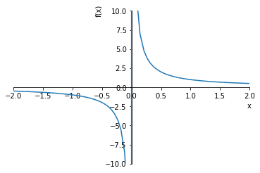

```
<sympy.plotting.plot.Plot at 0x7fb51ee93470>
```

```python
%matplotlib inline
from sympy.plotting import plot
x = symbols('x')
function = 1/x
plot(function, (x, -2, 2), ylim=(-10, 10))
```

```python
from sympy import limit
limit(function, x, 0)
```

$$\infty$$

```python
limit(function, x, 0, '-')
```

$$-\infty$$

```python
from sympy import oo
limit(function, x, oo)
```

$$0$$

```python
limit(function, x, -1*oo)
```

$$0$$

```python
from sympy import diff
x = symbols('x')
function = x**2
derivative = diff(function)
pprint(function)
print()
pprint(derivative)
```

```
 2
x

2⋅x
```

```python
(x**2).diff()
```

$$2 x$$

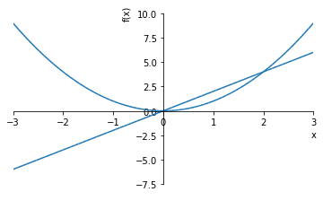

```
<sympy.plotting.plot.Plot at 0x7fb51cc9b0f0>
```

```python
plot(function, derivative, (x, -3, 3), ylim=(-10, 10))
```

## And now for some rocket science!

[figure not shown]

Images and stats taken from Kerbal Space Program (https://www.kerbalspaceprogram.com)

### Question: Will it get off the pad?

```python
from sympy import Eq, init_printing, symbols
init_printing()
force_net, weight_rocket, thrust_rocket = symbols('force_net weight_rocket thrust_rocket')
net_force_eqn = Eq(force_net, thrust_rocket - weight_rocket)
net_force_eqn
```

$$force_{net} = thrust_{rocket} - weight_{rocket}$$

```python
from collections import namedtuple

# Engine thrust in kilonewtons, weight in kilotonnes, specific impulse is in seconds
EngineStats = namedtuple('EngineStats', ['thrust', 'weight', 'Isp'])

ENGINE_DATA = {
    'skipper': EngineStats(568.75, 3, 280),
    'mainsail': EngineStats(1379.0, 6, 285),
}

BOOSTER_DATA = EngineStats(593.86, 24, 195) # Kickback booster

FUEL_TANK_WEIGHT = 36 # Rockomax Jumbo 64

GRAVITY = 9.8
```

```python
def get_rocket_thrust(engine_type, number_boosters=0):
    return sum([
        ENGINE_DATA[engine_type].thrust,
        number_boosters * BOOSTER_DATA.thrust,
    ])
```

```python
def get_rocket_mass(engine_type, number_tanks=1, number_boosters=0):
    "Returns rocket MASS in kilotonnes"
    return sum([
        0.2,  # Weight of nose cone,
        0.5,  # Weight of guidance unit,
        number_tanks * FUEL_TANK_WEIGHT,
        ENGINE_DATA[engine_type].weight,
        number_boosters * BOOSTER_DATA.weight,
    ])
```

```python
net_force_eqn
```

$$force_{net} = thrust_{rocket} - weight_{rocket}$$

```python
rocket_mass, G = symbols('rocket_mass G')
weight_eqn = Eq(weight_rocket, rocket_mass * G)
weight_eqn
```

$$weight_{rocket} = G rocket_{mass}$$

```python
net_force_eqn = net_force_eqn.subs(weight_eqn.lhs, weight_eqn.rhs)
net_force_eqn
```

$$force_{net} = - G rocket_{mass} + thrust_{rocket}$$

```python
net_force_eqn = net_force_eqn.subs(G, GRAVITY)
net_force_eqn
```

$$force_{net} = - 9.8 rocket_{mass} + thrust_{rocket}$$

[figure not shown]

```python
engine_type = 'skipper'
number_tanks = 4
net_force_eqn.subs([
    (rocket_mass, get_rocket_mass(engine_type, number_tanks)),
    (thrust_rocket, get_rocket_thrust(engine_type)),
])
```

$$force_{net} = -878.71$$

```python
engine_type = 'mainsail'
net_force_eqn.subs([
    (rocket_mass, get_rocket_mass(engine_type, number_tanks)),
    (thrust_rocket, get_rocket_thrust(engine_type))
])
```

$$force_{net} = -97.8599999999999$$

## ADD MORE BOOSTERS!!!!

[figure not shown]

```python
number_boosters = 4
net_force_eqn.subs([
    (rocket_mass, get_rocket_mass(engine_type, number_tanks, number_boosters)),
    (thrust_rocket, get_rocket_thrust(engine_type, number_boosters))
])
```

$$force_{net} = 1336.78$$

[figure not shown]

- http://sympy.org
- https://github.com/jocassid/talks
- @jocassid
- jocassid@gmail.com